# Practical Machine Learning Course Project - Prediction Exercise Manner

Hwee See

April 8, 2017

# Executive Summary

This report aim to predict the manner in which people did the Unilateral Dumbbell Biceps Curl exercise. The dataset used in this report - the Weight Lifting Exercises Dataset comprises of data from accelerometers on the belt, forearm, arm, and dumbell of 6 participants who were asked to perform barbell lifts in 5 different ways (Classe), which are exactly according to the specification (Class A), throwing the elbows to the front (Class B), lifting the dumbbell only halfway (Class C), lowering the dumbbell only halfway (Class D) and throwing the hips to the front (Class E). Only Class A corresponds to correct performance. This report will describe how the model was built, cross validation performed, and the expected out of sample error. The prediction model will then used to predict 20 different test cases.

# Data Processing

## Package Loading and Data Loading

```r
#This report use following libraries:
library(caret);
library(rattle);
```

```r
library(rpart);
library(rpart.plot)
library(randomForest);
```

The training and test data for this project come from this source: http://groupware.les.inf.puc-rio.br/har.

```r
# import the data from the URLs
trainurl <- "https://d396qusza40orc.cloudfront.net/predmachlearn/pml-training.csv"
testurl <- "https://d396qusza40orc.cloudfront.net/predmachlearn/pml-testing.csv"
if(!file.exists("./data")) {dir.create("./data")}
desttrainfilepath <- "./data/pml-training.csv"
desttestfilepath <- "./data/pml-testing.csv"
if(!file.exists(desttrainfilepath)) {download.file(trainurl,destfile = desttrainfilepath)}
if(!file.exists(desttestfilepath)) {download.file(testurl,destfile = desttestfilepath)}
trainingsource <- read.csv(desttrainfilepath)
testingsource  <- read.csv(desttestfilepath)
```

## Data Exploration

```r
str(trainingsource) #hide result
```

```r
summary(trainingsource) #hide result
```

The training data set consists of 19622 observations of 160 variables.  
Records with no records comes in in three forms: “NA”,“#DIV/0!”,“”.  
And there are also variables with less than 90% of records with value.

## Data Cleaning

Reload data with standardized na string, then remove all variables that contain > 90% missing values and the preceeding 7 variables that contains the exercise participants ID, name and non-sensor related information.

```r
#reload records with standardized na string for no value
trainingsource <- read.csv(desttrainfilepath, na.strings = c("NA","#DIV/0!",""))
testingsource  <- read.csv(desttestfilepath, na.strings = c("NA","#DIV/0!",""))
# remove variables that are mostly NA
manyNA    <- sapply(trainingsource, function(x) mean(is.na(x))) > 0.90
trainset <- trainingsource[, manyNA==FALSE]
testset  <- testingsource[, manyNA==FALSE]
# remove participants information & non-sensor related variables
trainset <- trainset[, -(1:7)]
testset  <- testset[, -(1:7)]
```

```r
str(trainset)
```

```
## 'data.frame':    19622 obs. of  53 variables:
##  $ roll_belt           : num  1.41 1.41 1.42 1.48 1.48 1.45 1.42 1.42 1.43 1.45 ...
##  $ pitch_belt          : num  8.07 8.07 8.07 8.05 8.07 8.06 8.09 8.13 8.16 8.17 ...
##  $ yaw_belt            : num  -94.4 -94.4 -94.4 -94.4 -94.4 -94.4 -94.4 -94.4 -94.4 -94.4 ...
##  $ total_accel_belt    : int  3 3 3 3 3 3 3 3 3 3 ...
##  $ gyros_belt_x        : num  0 0.02 0 0.02 0.02 0.02 0.02 0.02 0.02 0.03 ...
##  $ gyros_belt_y        : num  0 0 0 0 0.02 0 0 0 0 0 ...
##  $ gyros_belt_z        : num  -0.02 -0.02 -0.02 -0.03 -0.02 -0.02 -0.02 -0.02 -0.02 0 ...
##  $ accel_belt_x        : int  -21 -22 -20 -22 -21 -21 -22 -22 -20 -21 ...
##  $ accel_belt_y        : int  4 4 5 3 2 4 3 4 2 4 ...
##  $ accel_belt_z        : int  22 22 23 21 24 21 21 21 24 22 ...
##  $ magnet_belt_x       : int  -3 -7 -2 -6 -6 0 -4 -2 1 -3 ...
##  $ magnet_belt_y       : int  599 608 600 604 600 603 599 603 602 609 ...
##  $ magnet_belt_z       : int  -313 -311 -305 -310 -302 -312 -311 -313 -312 -308 ...
##  $ roll_arm            : num  -128 -128 -128 -128 -128 -128 -128 -128 -128 -128 ...
```

[output cut: 39 more lines]

Resulting training set is 19622 observations with 53 variables.

## Data Spliting

Next, the training set will be split into training set (70%) and testing set (30%).

```r
set.seed(12345)
inTrain <- createDataPartition(trainset$classe, p = 0.7, list = FALSE)
modeltrain <- trainset[inTrain, ]
modeltest <- trainset[-inTrain, ]
```

# Build the Prediction Model

Three algorithm will be applied to model the prediction using the train set. Prediction will be testify using the test set. And the methods with the highest accuracy will be choosen.

## 1. Random forest (rf)

```r
#random forest with cross validation
modelRF <- train(classe ~.,data = modeltrain,method = 'rf',trControl=trainControl(method = "cv", number = 4))
modelRF$finalModel
```

```
##
## Call:
##  randomForest(x = x, y = y, mtry = param$mtry)
##                Type of random forest: classification
##                      Number of trees: 500
## No. of variables tried at each split: 27
##
##         OOB estimate of  error rate: 0.86%
## Confusion matrix:
##      A    B    C    D    E class.error
## A 3900    2    2    0    2 0.001536098
## B   22 2625   10    1    0 0.012415350
## C    0   17 2364   15    0 0.013355593
## D    0    3   25 2219    5 0.014653641
## E    0    1    6    7 2511 0.005544554
```

```r
predictRF <- predict(modelRF, newdata=modeltest)
confmatRF <- confusionMatrix(predictRF, modeltest$classe)
confmatRF
```

```
## Confusion Matrix and Statistics
##
##           Reference
## Prediction    A    B    C    D    E
##          A 1671   10    0    0    0
##          B    3 1125    6    0    0
##          C    0    4 1015   13    1
##          D    0    0    5  951    5
##          E    0    0    0    0 1076
##
## Overall Statistics
##
##                Accuracy : 0.992
##                  95% CI : (0.9894, 0.9941)
##     No Information Rate : 0.2845
##     P-Value [Acc > NIR] : < 2.2e-16
##
##                   Kappa : 0.9899
##  Mcnemar's Test P-Value : NA
##
## Statistics by Class:
##
##                      Class: A Class: B Class: C Class: D Class: E
## Sensitivity            0.9982   0.9877   0.9893   0.9865   0.9945
## Specificity            0.9976   0.9981   0.9963   0.9980   1.0000
## Pos Pred Value         0.9941   0.9921   0.9826   0.9896   1.0000
## Neg Pred Value         0.9993   0.9971   0.9977   0.9974   0.9988
## Prevalence             0.2845   0.1935   0.1743   0.1638   0.1839
## Detection Rate         0.2839   0.1912   0.1725   0.1616   0.1828
## Detection Prevalence   0.2856   0.1927   0.1755   0.1633   0.1828
## Balanced Accuracy      0.9979   0.9929   0.9928   0.9922   0.9972
```

The model accuracy is 0.9920136.

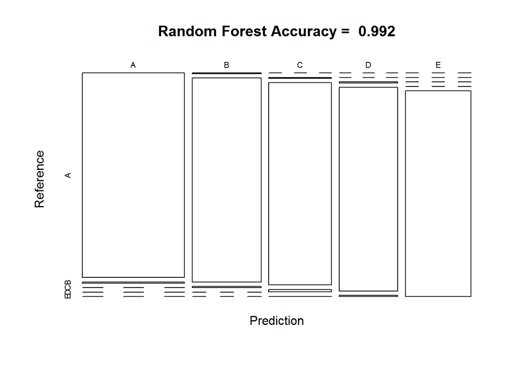

```r
# plot confusion matrix
plot(confmatRF$table, col = confmatRF$byClass, main = paste("Random Forest Accuracy = ", round(confmatRF$overall['Accuracy'], 4)))
```

## 2. Decision trees (rpart)

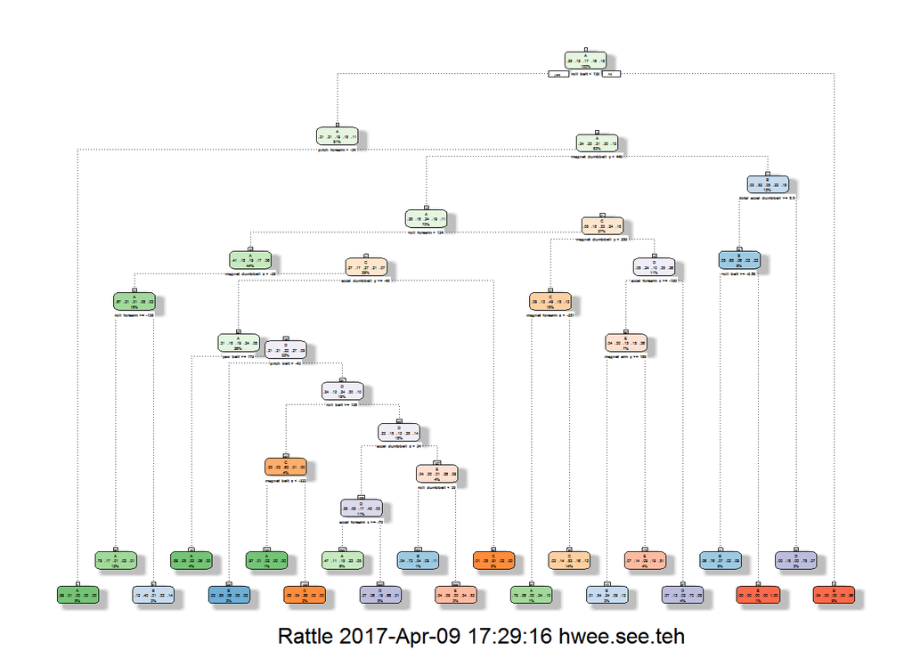

```r
modelDT <- rpart(classe ~ ., data=modeltrain, method="class")
fancyRpartPlot(modelDT)
```

```r
predictDT <- predict(modelDT, modeltest, type = "class")
confmatDT <- confusionMatrix(predictDT, modeltest$classe)
confmatDT
```

```
## Confusion Matrix and Statistics
##
##           Reference
## Prediction    A    B    C    D    E
##          A 1498  196   69  106   25
##          B   42  669   85   86   92
##          C   43  136  739  129  131
##          D   33   85   98  553   44
##          E   58   53   35   90  790
##
## Overall Statistics
##
##                Accuracy : 0.722
##                  95% CI : (0.7104, 0.7334)
##     No Information Rate : 0.2845
##     P-Value [Acc > NIR] : < 2.2e-16
##
##                   Kappa : 0.6467
##  Mcnemar's Test P-Value : < 2.2e-16
##
## Statistics by Class:
##
##                      Class: A Class: B Class: C Class: D Class: E
## Sensitivity            0.8949   0.5874   0.7203  0.57365   0.7301
## Specificity            0.9060   0.9357   0.9097  0.94717   0.9509
## Pos Pred Value         0.7909   0.6869   0.6273  0.68020   0.7700
## Neg Pred Value         0.9559   0.9043   0.9390  0.91897   0.9399
## Prevalence             0.2845   0.1935   0.1743  0.16381   0.1839
## Detection Rate         0.2545   0.1137   0.1256  0.09397   0.1342
## Detection Prevalence   0.3218   0.1655   0.2002  0.13815   0.1743
## Balanced Accuracy      0.9004   0.7615   0.8150  0.76041   0.8405
```

The model accuracy is 0.7220051.

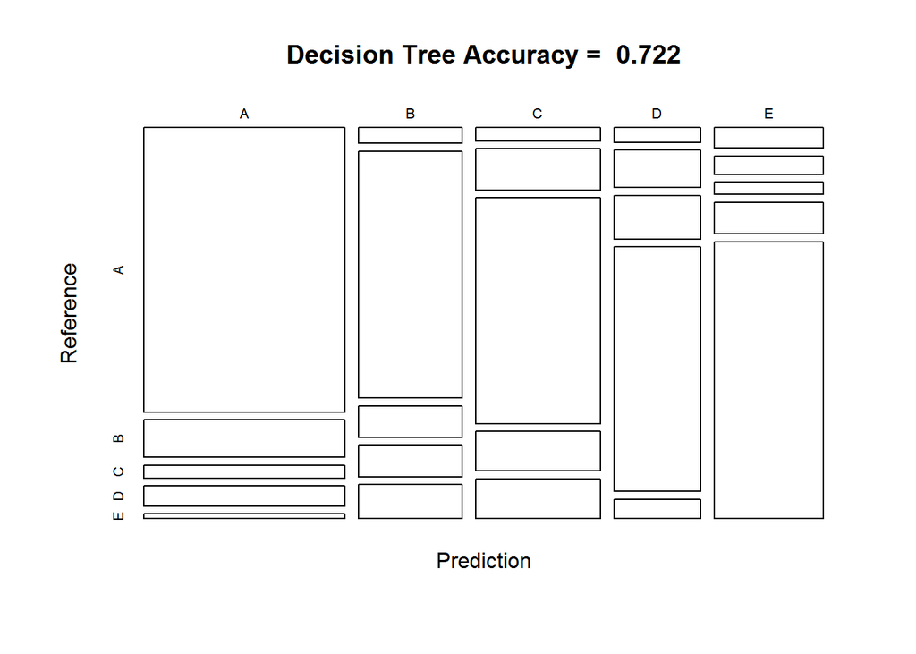

```r
# plot confusion matrix
plot(confmatDT$table, col = confmatDT$byClass, main = paste("Decision Tree Accuracy = ", round(confmatDT$overall['Accuracy'], 4)))
```

## 3. Generalized Boosted Model (gbm)

```r
#use repeated cross validation
controlGBM <- trainControl(method = "repeatedcv", number = 5, repeats = 1)
modelGBM  <- train(classe ~ ., data=modeltrain, method = "gbm", trControl = controlGBM, verbose = FALSE)
modelGBM$finalModel
```

```
## A gradient boosted model with multinomial loss function.
## 150 iterations were performed.
## There were 52 predictors of which 44 had non-zero influence.
```

```r
predictGBM <- predict(modelGBM, newdata=modeltest)
confmatGBM <- confusionMatrix(predictGBM, modeltest$classe)
confmatGBM
```

```
## Confusion Matrix and Statistics
##
##           Reference
## Prediction    A    B    C    D    E
##          A 1650   39    0    2    2
##          B   20 1068   33    4   15
##          C    1   30  979   39    4
##          D    3    2   12  916   19
##          E    0    0    2    3 1042
##
## Overall Statistics
##
##                Accuracy : 0.9609
##                  95% CI : (0.9556, 0.9657)
##     No Information Rate : 0.2845
##     P-Value [Acc > NIR] : < 2.2e-16
##
##                   Kappa : 0.9505
##  Mcnemar's Test P-Value : 1.283e-07
##
## Statistics by Class:
##
##                      Class: A Class: B Class: C Class: D Class: E
## Sensitivity            0.9857   0.9377   0.9542   0.9502   0.9630
## Specificity            0.9898   0.9848   0.9848   0.9927   0.9990
## Pos Pred Value         0.9746   0.9368   0.9297   0.9622   0.9952
## Neg Pred Value         0.9943   0.9850   0.9903   0.9903   0.9917
## Prevalence             0.2845   0.1935   0.1743   0.1638   0.1839
## Detection Rate         0.2804   0.1815   0.1664   0.1556   0.1771
## Detection Prevalence   0.2877   0.1937   0.1789   0.1618   0.1779
## Balanced Accuracy      0.9877   0.9612   0.9695   0.9714   0.9810
```

The model accuracy is 0.9609176.

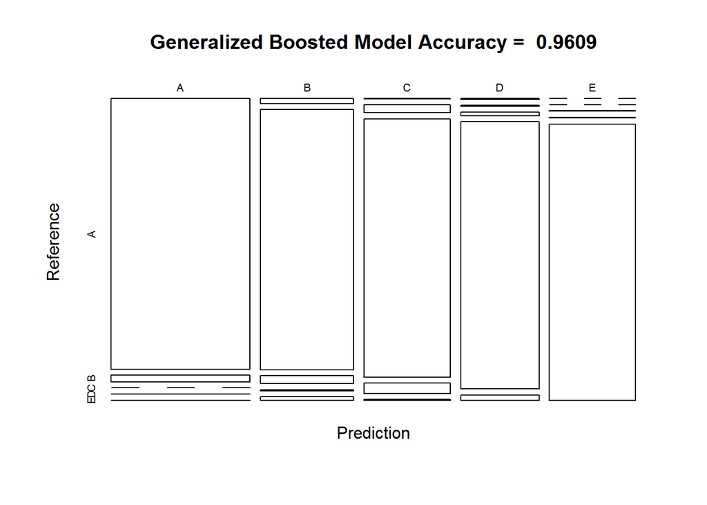

```r
# plot confusion matrix
plot(confmatGBM$table, col = confmatGBM$byClass, main = paste("Generalized Boosted Model Accuracy = ", round(confmatGBM$overall['Accuracy'], 4)))
```

# Conclusion

The accuracy and it’s expected out-of-sample error of the three models are:

| No | Model | Accuracy | Expected out-of-sample Error |
| --- | --- | --- | --- |
| 1. | Random forest (rf) | 99.2013594 | 0.7986406 |
| 2. | Decision trees (rpart) | 72.2005098 | 27.7994902 |
| 3. | Generalized Boosted Model (gbm) | 96.0917587 | 3.9082413 |

# Predicting Test Cases

The Random Forest model with the highest accuracy will be choosed to predict the given 20 testing set.

```r
predicttestset <- predict(modelRF, newdata=testset)
predicttestset
```

```
##  [1] B A B A A E D B A A B C B A E E A B B B
## Levels: A B C D E
```